# PA1-template.Rmd

David N. Cohron

January 13, 2016

# Activity Monitoring Analysis

## Johns Hopkins University- Coursera

## Project #1

### Overview:

#### This project is designed to produce a report from raw data. Data source is a personal activity monitoring device worn by an anonymous individual for 61 days during October and November 2012 and included the number of steps taken in 5 minute intervals each day.

### The Data:

#### The variables included in this dataset are:

#### steps: Number of steps taking in a 5-minute interval (missing values are coded as 𝙽𝙰)

#### date: The date on which the measurement was taken in YYYY-MM-DD format

#### interval: Identifier for the 5-minute interval in which measurement was taken

#### The dataset is stored in a comma-separated-value (CSV) file and there are a total of 17,568 observations in this dataset.

### Course Assignment:

1. Code for reading in the dataset and/or processing the data

```r
# some general housekeeping to get started
# globally suppress warnings
oldwarn<- getOption("warn")
options(warn = -1)

# install libraries/packages
library(plyr)
library(dplyr)
library(lubridate)
```

```r
# read file into data frame for manipulation
file<- "activity.csv"
main<- read.csv(file)

# refactor raw date to type date
main<- mutate(main, date=as.Date(as.character(main$date)))
```

2. Histogram of the total number of steps taken each day

```r
# group by days to get sum of steps per day
# ignore days with no steps recorded
stepsbyday<- group_by(main, date) %>% summarize_each(funs(sum))
na.omit(stepsbyday)
```

```
## Source: local data frame [53 x 3]
##
##          date steps interval
##        (date) (int)    (int)
## 1  2012-10-02   126   339120
## 2  2012-10-03 11352   339120
## 3  2012-10-04 12116   339120
## 4  2012-10-05 13294   339120
## 5  2012-10-06 15420   339120
## 6  2012-10-07 11015   339120
## 7  2012-10-09 12811   339120
## 8  2012-10-10  9900   339120
## 9  2012-10-11 10304   339120
## 10 2012-10-12 17382   339120
## ..        ...   ...      ...
```

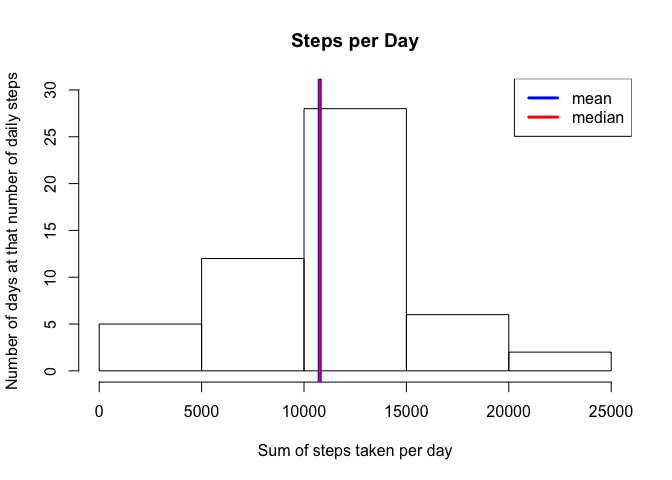

```r
#calculate mean and median of number of steps per day
meansteps<-mean(stepsbyday$steps, na.rm=TRUE)
mediansteps<- median(stepsbyday$steps, na.rm=TRUE)

# plot histogram
hist(stepsbyday$steps,
     main = "Steps per Day",
     xlab = "Sum of steps taken per day",
     ylab = "Number of days at that number of daily steps",
     xlim = c(0, 25000),
     ylim = c(0, 30))

abline(v = meansteps, col = "blue", lwd=4)
abline(v = mediansteps, col = "red", lwd=2)

legend('topright',
       c("mean", "median"),
       col=c("blue", "red"),
       lwd=3)
```

3. Mean and median number of steps taken each day Note that the mean and the median are quite close.

```r
# calculate mean and median of number of steps per day
# note: this is already reflected on the histogram
meansteps<-mean(stepsbyday$steps, na.rm=TRUE)
meansteps
```

```
## [1] 10766.19
```

```r
mediansteps<- median(stepsbyday$steps, na.rm=TRUE)
mediansteps
```

```
## [1] 10765
```

4. Time series plot of the average number of steps taken

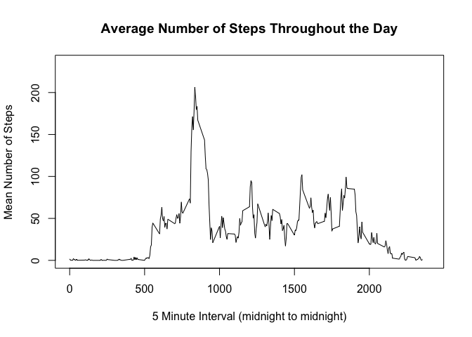

```r
# group by 5 minute interval
# ignore intervals with no steps recorded
stepsbyinterval<- group_by(main, interval) %>% summarize_each(funs(mean(., na.rm=TRUE)))

# plot time series of 5 minute interval average steps
with(stepsbyinterval, plot(interval, steps,
                           type = "l",
                           main = "Average Number of Steps Throughout the Day",
                           xlab = "5 Minute Interval (midnight to midnight)",
                           ylab = "Mean Number of Steps",
                           xlim = c(0, 2400),
                           ylim = c(0, 235)))
```

5. The 5-minute interval that, on average, contains the maximum number of steps

```r
# calculate which 5 minute interval has highest average number of steps
maxintervalrow<- which.max(stepsbyinterval$steps)
maxinterval<- stepsbyinterval$interval[maxintervalrow]
maxinterval
```

```
## [1] 835
```

```r
maxavgsteps<- stepsbyinterval$steps[maxintervalrow]
maxavgsteps
```

```
## [1] 206.1698
```

6. Code to describe and show a strategy for imputing missing data

```r
# calculate  and report the number of rows with missing (NA) data
numrowtotal<- nrow(main)
numrownona<- nrow(na.omit(main))
numrowwithna<- numrowtotal - numrownona
numrowwithna
```

```
## [1] 2304
```

```r
# impute missing values and replace with interval mean
impute.mean <- function(x) replace(x, is.na(x), mean(x, na.rm = TRUE))
mainimputed <- ddply(main, ~ interval, transform, steps = impute.mean(steps))
```

```r
# group new data frame by days to get sum of steps per day
# all days/intervals have steps recorded
stepsbyday2<- group_by(mainimputed, date) %>% summarize_each(funs(sum))

# calculate mean and median of number of steps per day
meansteps2<-mean(stepsbyday2$steps)
meansteps2
```

```
## [1] 10766.19
```

```r
mediansteps2<- median(stepsbyday2$steps)
mediansteps2
```

```
## [1] 10766.19
```

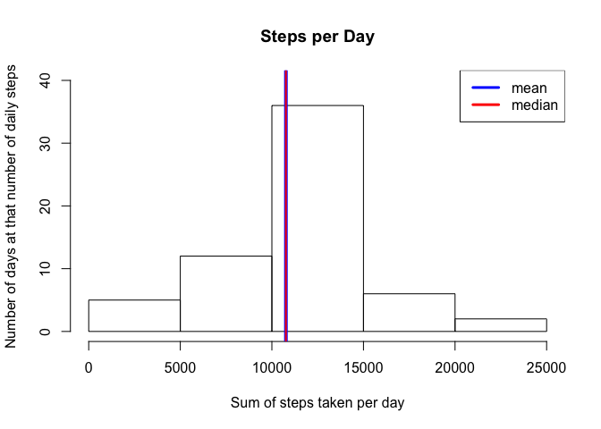

```r
# plot histogram on imputed data
hist(stepsbyday2$steps,
     main = "Steps per Day",
     xlab = "Sum of steps taken per day",
     ylab = "Number of days at that number of daily steps",
     xlim = c(0, 25000),
     ylim = c(0, 40))

abline(v = meansteps2, col = "blue", lwd=4)
abline(v = mediansteps2, col = "red", lwd=2)

legend('topright',
       c("mean", "median"),
       col=c("blue", "red"),
       lwd=3)
```

8. Panel plot comparing the average number of steps taken per 5-minute interval across weekdays and weekends

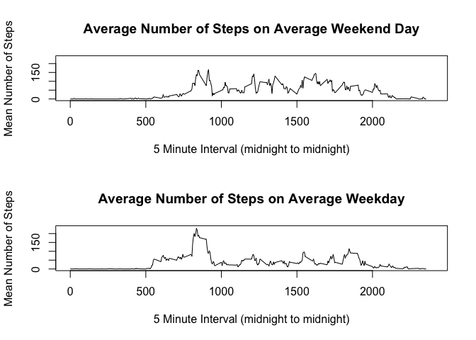

```r
# add columns showing day of the week
stepsbyday3<- mutate(mainimputed, dayofweek = weekdays(date, abbreviate=TRUE))

# add column with logical vector as to weekday/weekend
stepsbyday3<- mutate(stepsbyday3, weekend = (dayofweek == "Sun" | dayofweek == "Sat"))

# subset for weekday and weekend in new data frames
weekdaysteps<- subset(stepsbyday3, !weekend)
weekendsteps<- subset(stepsbyday3, weekend)

# convert logical vector to factors with labels
# Note: I did not need to do this for my analysis,
#       but it was a requirement of the project
stepsbyday3$weekend<-factor(stepsbyday3$weekend,levels=c(FALSE, TRUE), labels=c('Weekday', 'Weekend'))

#group by date
weekdaystepsum<- group_by(weekdaysteps, date) %>% summarize_each(funs(sum(steps)))
weekendstepsum<- group_by(weekendsteps, date) %>% summarize_each(funs(sum(steps)))

# calculate mean and median of number of steps per day
meanstepsweekday<-mean(weekdaystepsum$steps)
medianstepsweekend<- median(weekendstepsum$steps)

# group by 5 minute interval
# ignore intervals with no steps recorded
weekdaystepsbyinterval<- group_by(weekdaysteps, interval) %>% summarize_each(funs(mean(., na.rm=TRUE)))
weekendstepsbyinterval<- group_by(weekendsteps, interval) %>% summarize_each(funs(mean(., na.rm=TRUE)))

# plot time series of 5 minute interval average steps for weekday and weekends
# Note:  I did not try to duplicate the example exactly. I believe this is more clear.
layout(matrix(c(2,1), byrow = TRUE),
       widths=c(1,1), heights=c(3,3))
with(weekdaystepsbyinterval, plot(interval, steps,
                                  type = "l",
                                  main = "Average Number of Steps on Average Weekday",
                                  xlab = "5 Minute Interval (midnight to midnight)",
                                  ylab = "Mean Number of Steps",
                                  xlim = c(0, 2400),
                                  ylim = c(0, 235)))

with(weekendstepsbyinterval, plot(interval, steps,
                                  type = "l",
                                  main = "Average Number of Steps on Average Weekend Day",
                                  xlab = "5 Minute Interval (midnight to midnight)",
                                  ylab = "Mean Number of Steps",
                                  xlim = c(0, 2400),
                                  ylim = c(0, 235)))
```

9. All of the R code needed to reproduce the results (numbers, plots, etc.) in the report

```r
# restore warnings
options(warn = oldwarn)
```